# Regression Discontinuity

EC 325: Econometrics

Prof. Caraher

Colby College

2026-04-29

## Where We’ve Been

- Our causal inference toolkit so far:
  - **RCTs**: random assignment by design
  - **Multivariate OLS**: control for selection on observables
  - **Fixed effects**: absorb time-invariant unobservables
  - **DiD**: control units net out common trends
  - **IV**: exogenous variation from an instrument
- All require finding variation in $X$ that is **as good as random** or **totally exogenous**
- Today: one more tool — one of the cleanest — **regression discontinuity (RD)**

## The Big Idea

- Modern life is full of **rigid rules and cutoffs**:
- Turn 21 $\to$ legal drinking
- Score 70+ on an exam $\to$ admitted to a selective school
- Income below threshold $\to$ qualify for Medicaid
- 50.01% vote share $\to$ win the election
- At the cutoff, treatment flips on (or off) **abruptly**
- Units just above and just below are nearly identical *except* for treatment
- $\to$ rigid rules generate **natural experiments**

# The RD Intuition

## A Jump at the Cutoff

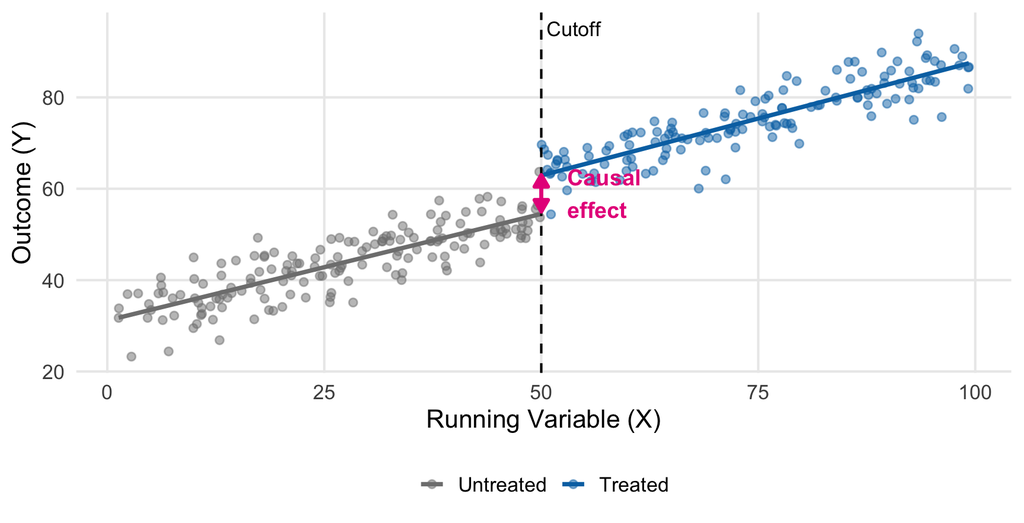

Figure 1

## Key Vocabulary

**Three terms you need to know**

- **Running variable** (or *forcing variable*): the continuous variable whose value determines treatment (e.g., age, test score, vote share).
- **Cutoff** (or *threshold*): the value of the running variable at which treatment flips (e.g., age 21, 70%, 50%).
- **Sharp RD**: treatment is a *deterministic* function of the running variable — 0 below the cutoff, 1 above (or vice versa).
- Today we focus on **sharp** RD
- A *fuzzy* variant exists (cutoff shifts the *probability* of treatment) — handled with IV

# Running Example: The MLDA

## Birthdays and Funerals

- Carpenter & Dobkin (2009): does the **minimum legal drinking age** of 21 save lives?
- Hard to answer with regular tools:
  - Can’t randomize legal drinking age
  - Before/after comparisons confound aging with drinking
- But the MLDA itself runs the experiment for us:
  - On your 21st birthday, legal access flips on
  - Yesterday’s you and today’s you are essentially identical, *except for the fact that you are now 21*
- Compare death rates **just below** and **just above** age 21

## Simulating Carpenter & Dobkin

```r
set.seed(234)

mlda_data <- tibble(months = seq(-24, 23, by = 1)) |>
    mutate(
        over21 = as.numeric(months >= 0),
        # True jump = 7.7 deaths per 100,000 (AP Table 4.1)
        death_rate = 90 - 0.15 * months + 7.7 * over21 +
                     rnorm(n(), 0, 1)
    )
```

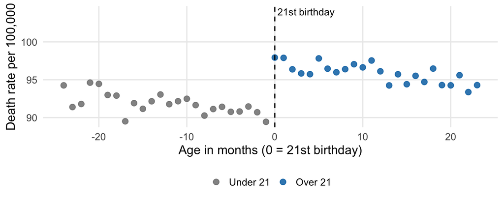

Figure 2

# The Sharp RD Regression

## A Linear Model

- Simplest sharp RD specification:

$$Y_a = \alpha + \rho D_a + \gamma a + e_a$$

- $D_a = 1$ if $a \geq a_0$, else 0
- $\gamma a$ controls for the **smooth trend** in the running variable
- $\rho$ = the **vertical jump** at the cutoff $\to$ our causal estimate

**What makes RD special**

Treatment is a deterministic function of the running variable. Control for the running variable correctly $\to$ no classical OVB. The *whole* identification argument lives in modeling that one trend.

## Estimating It

```r
simple_rd <- feols(death_rate ~ over21 + months,
                   vcov = "HC1",
                   data = mlda_data)

summary(simple_rd)
```

```
OLS estimation, Dep. Var.: death_rate
Observations: 48
Standard-errors: Heteroskedasticity-robust
             Estimate Std. Error   t value      Pr(>|t|)
(Intercept) 90.235049   0.239522 376.72891     < 2.2e-16 ***
over21       7.112803   0.460994  15.42928     < 2.2e-16 ***
months      -0.129009   0.020691  -6.23497 0.00000013975 ***
---
Signif. codes:  0 '***' 0.001 '**' 0.01 '*' 0.05 '.' 0.1 ' ' 1
RMSE: 0.955263   Adj. R2: 0.834052
```

- Coefficient on `over21` $\to$ estimate of the MLDA jump
- Should land near the true $\rho = 7.7$

## Visualizing the Fit

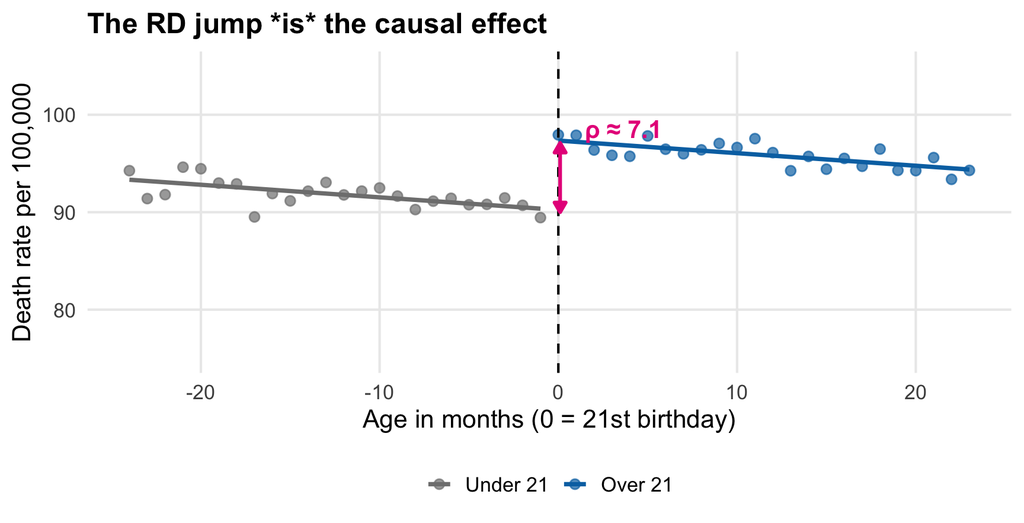

Figure 3

## Linear Isn’t Always Enough

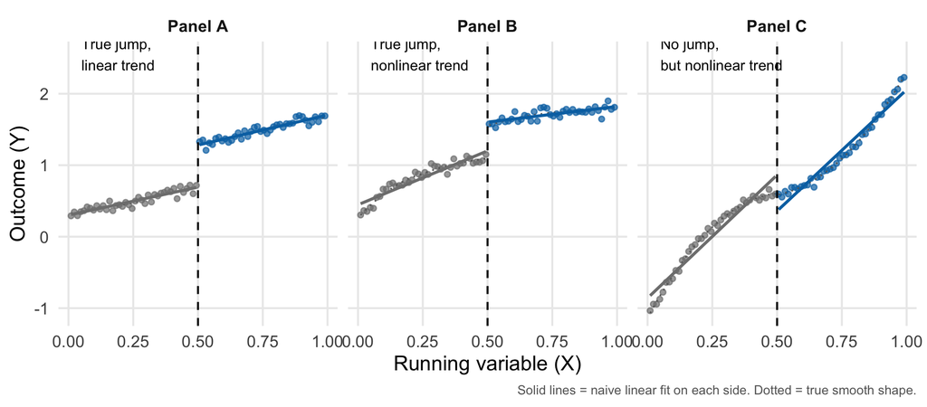

Figure 4

- Panel C is the danger: a **smooth curve** with no real jump can *look* like a jump under a naive linear fit

## Two Ways to Handle Nonlinearity

**1. Parametric**

- Add polynomials & interactions
- Let the slope (and curvature) bend differently on each side of the cutoff
- Uses *all* the data

**2. Nonparametric**

- Restrict to a narrow window around the cutoff
- Over a small window, any smooth curve looks linear
- Uses only data *near* the cutoff
- Both are useful. Best practice: report **both** and show the answer is stable.

## Parametric: Three Specifications

```r
rd_linear     <- feols(death_rate ~ over21 + months,
                       vcov = "HC1", data = mlda_data)

rd_linear_int <- feols(death_rate ~ over21 + months + months:over21,
                       vcov = "HC1", data = mlda_data)

rd_quad       <- feols(death_rate ~ over21 + months + I(months^2) +
                           months:over21 + I(months^2):over21,
                       vcov = "HC1", data = mlda_data)
```

- **Linear**: same slope on each side
- **Linear, interacted**: different slopes on each side
- **Quadratic, interacted**: different curvatures, too

## Parametric: Visual Comparison

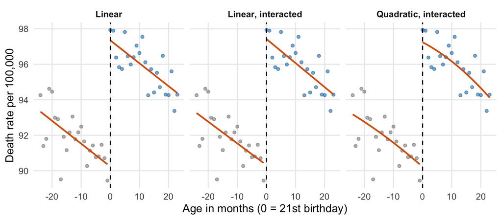

Figure 5

- Estimates are stable across specs $\to$ **a hallmark of credible RD**

**Don’t go higher than quadratic**

4th- or 5th-order polynomials chase noise near the boundaries and *invent* jumps. Gelman & Imbens (2019) recommend stopping at quadratic and using local linear regression instead.

# Nonparametric RD

## Bandwidth: A Bias-Variance Tradeoff

- Restrict to $|a - a_0| \leq b$ for some bandwidth $b$
- Then run a simple linear RD inside the window

**Narrow bandwidth**

- Less data $\to$ bigger SE
- Less room for nonlinearity to bite
- $\to$ **lower bias, higher variance**

**Wide bandwidth**

- More data $\to$ smaller SE
- More chance to mistake curvature for a jump
- $\to$ **higher bias, lower variance**

## Trying Three Bandwidths

```r
rd_b24 <- feols(death_rate ~ over21 + months,
                vcov = "HC1",
                data = subset(mlda_data, abs(months) <= 24))

rd_b12 <- feols(death_rate ~ over21 + months,
                vcov = "HC1",
                data = subset(mlda_data, abs(months) <= 12))

rd_b06 <- feols(death_rate ~ over21 + months,
                vcov = "HC1",
                data = subset(mlda_data, abs(months) <= 6))
```

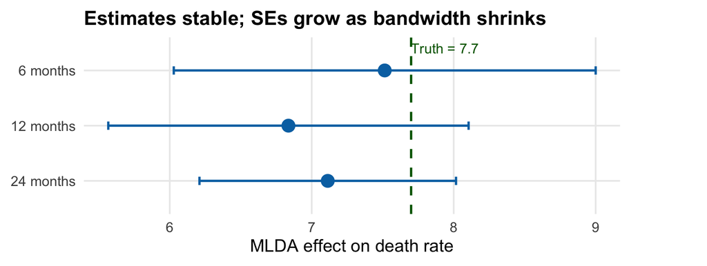

Figure 6

# Validity Checks

## Falsification: Cause-Specific Effects

- If we’re really picking up the effect of *legal drinking*, the jump should appear in alcohol-driven causes (motor vehicles, suicide) but **not** in unrelated causes (heart disease, cancer)

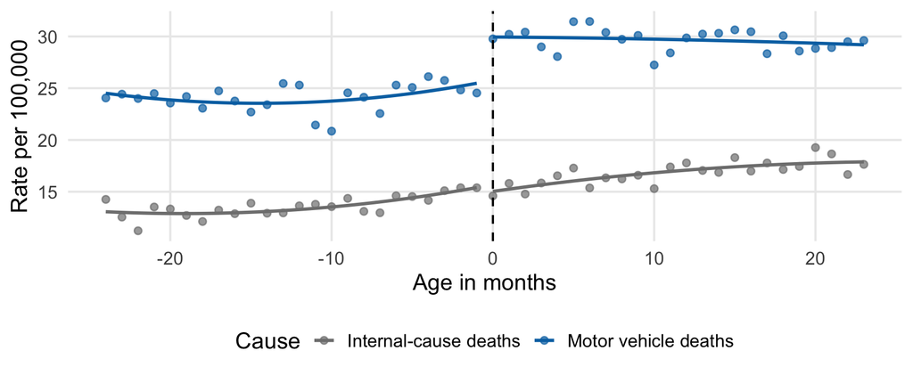

Figure 7

- Big jump where alcohol matters; nothing where it doesn’t $\to$ design looks credible

## Manipulation: Density Tests

- If units can **engineer** their position relative to the cutoff (think: a manager rounding test scores up), the design breaks
- Diagnostic: plot the density of the running variable. A pile-up just on one side is a red flag.

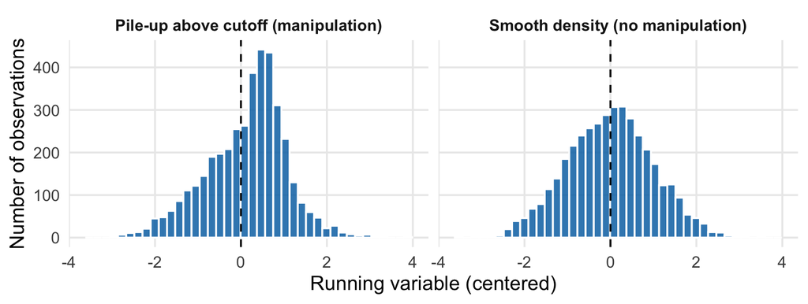

Figure 8

- Formal test: McCrary (2008); modern version in the `rddensity` package

## Other Validity Checks

**A credible RD paper shows…**

1. **Covariate balance**: pre-determined characteristics (age, gender, prior outcomes) don’t jump at the cutoff
2. **Density smoothness**: no pile-up of the running variable on either side
3. **Robustness**: the jump survives different bandwidths and polynomial orders
4. **Placebo cutoffs**: estimating “effects” at fake cutoffs gives ~ 0
5. **Falsification outcomes**: outcomes treatment shouldn’t affect… aren’t affected

# Wrapping Up

## Key Takeaways

- **RD turns rigid rules into natural experiments** by comparing units just above and just below a cutoff
- **Sharp RD**: treatment is a deterministic function of a running variable
- The estimate $\rho$ is the **vertical jump** in the outcome at the cutoff
- Two strategies for handling nonlinearity:
  - **Parametric** (polynomials & interactions; stop at quadratic)
  - **Nonparametric** (zoom in on a bandwidth; use `rdrobust` in practice)
- Validate with covariate balance, density smoothness, falsification outcomes, and placebo cutoffs

**The RD pitch in one sentence**

*Here is the rule, here is the cutoff, here is the jump — and here is why nothing else can explain it.*